The Lads Travel Co.

# Iceland. Four ways to *do it right.*

One island. Two seasons that don't share a single thing except the geography. Four frameworks built from firsthand experience driving the full Ring Road — and the research to cover what we haven't seen in winter.

FormatGroup of 4 / Rental car

ValidatedFull Ring Road, Summer

Versions4 frameworks

Iceland is one of the most accessible, self-drivable, genuinely otherworldly places on the planet. The Ring Road gives you a complete story. The South Coast gives you the best of it in less time. Either way, the group comes home with something most people are not talking about yet.

Dawson completed the full Ring Road in summer — 10 days, five stops, every section of Route 1. That personal experience grounds everything in Versions 1 and 2. The winter versions are built from research, validated against the same geography, and flagged honestly where the knowledge shifts from firsthand to sourced.

Below: pick your season, pick your duration, and get the full framework. Everything you need to make real decisions and book a real trip.

Quick Read

## Iceland at a glance

Four versions of the same island. Summer or winter. Short loop or full Ring Road. Dawson completed the full summer Ring Road and rates it as one of the best trips he has done. The Westman Islands are the personal standout — puffins, volcanic hiking, and a ferry that costs less than a Reykjavik dinner.

Late June is the window. Midnight sun, puffins, lupine fields, and six weeks before the August 2026 eclipse pricing surge. Winter means northern lights, ice caves, and 30-40% lower ground costs — but harder driving and no guarantees on the aurora.

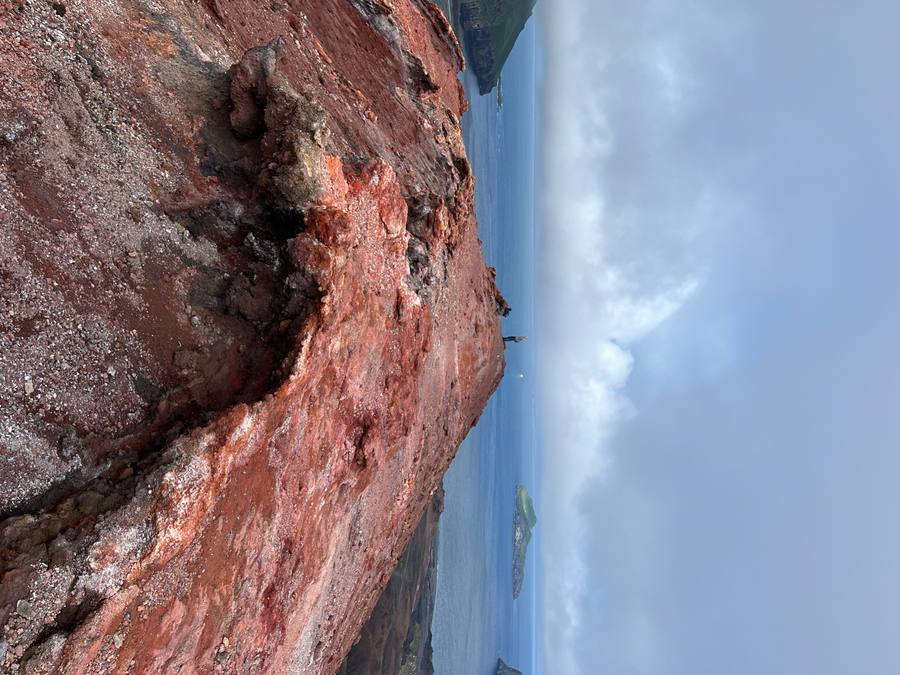

Critical — August 2026

A total solar eclipse crosses western Iceland — including Reykjavik — on August 12, 2026. Hotels were largely sold out more than 14 months in advance. Flights from North America are running 200-300% above standard summer rates. Car rental availability is critically low. If you are not specifically targeting the eclipse, avoid the first three weeks of August 2026 entirely. Late June is better on every metric.

Choose Your Iceland

## Two seasons. Two different planets.

Summer Iceland and winter Iceland share geography and nothing else. The light, the landscape, the wildlife, the cost, the risk, the reward — all different. Pick the one that matches what you actually want.

### Midnight Sun

Late June

24-hour daylight. Puffins. Lupine fields. Green landscapes. Everything open. The version most people picture when they think of Iceland. Easier to execute, higher ground cost.

### Northern Lights

Late Feb / Early March

Aurora hunting. Ice caves. Hot springs in the cold. Stark volcanic landscapes under snow. Fewer people at every stop. 30-40% cheaper on the ground. Harder driving.

Version 1

## Summer Short — 5 to 7 Days

Reykjavik + Golden Circle + South Coast — Late June

High Confidence

The efficient first-timer's Iceland. Covers every iconic South Coast stop without the full Ring Road commitment. This is the version one of the Lads recommends for groups with limited time — it delivers the highlights in a manageable timeframe with almost no wasted miles.

Dawson

A shorter trip should focus on Reykjavik, Golden Circle, and the South Coast. That corridor covers the highlights — lighthouses and shipwrecks near Selfoss, the Blue Lagoon area, Westman Islands as a day trip, Thingvellir, Gulfoss, lupine fields, Icelandic horses. It gets quiet after Glacier Lagoon heading east.

Research Adds

Late June is the sweet spot — midnight sun at its peak, puffins fully active on the Westman Islands, lupine bloom at maximum, most F-roads just opening for inland detours. Predates the August eclipse pricing surge by six full weeks.

### Day by Day

Day 1

Arrival + Grindavik Peninsula

Fly into KEF. Buy all alcohol at duty-free — this is not optional, it is 2-3x cheaper than anything on the island. Drive toward Selfoss. Stop at the Grindavik Peninsula for lighthouses, shipwrecks, and the Bridge Between Continents. Blue Lagoon walk-through optional — skip the full spa.

Day 2

Westman Islands

Full day via car ferry from Landeyjahofn. Hike Eldfell volcano. Southern peninsula loop for the puffin colony. The eruption museum is worth your time — documents the volcanic evacuation that shaped the islands.

Dawson

This is the personal highlight of the entire trip. The islands are crazy beautiful. The ferry can get bumpy. Budget the whole day — you will not regret it. Best bang-for-buck excursion in Iceland.

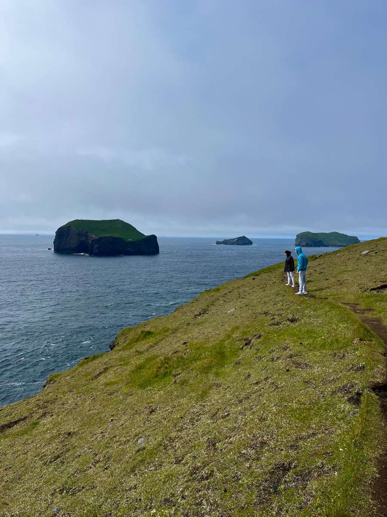

Day 3

Golden Circle

Thingvellir National Park — solid hiking, tectonic plate boundary visible. Gulfoss waterfall. Lupine fields and Icelandic horses along the route. This is the most-visited corridor in Iceland for a reason.

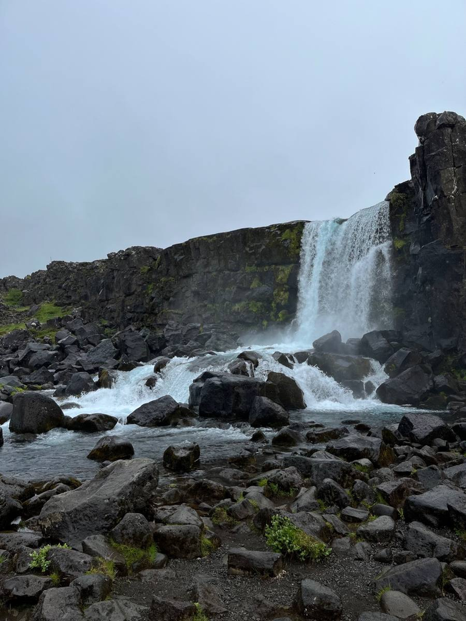

Days 4-5

South Coast to Diamond Beach

Seljalandsfoss, Skogafoss, Reynisfjara black sand beach, Dyrholaey. Push to Diamond Beach and Glacier Lagoon — huge icebergs and pieces of glacial ice washing up on black sand.

Dawson

Great view of glaciers. Huge icebergs. The ice on the black sand is very pretty — it looks like it should not be real.

Days 6-7

Return + Reykjavik

Drive back along the South Coast or base out of Reykjavik for the final days. Hallgrimskirkja church. Sun Voyager sculpture. Hrunalaug hot spring ($15, almost no one around) or Sky Lagoon ($70, better views than Blue Lagoon at a fraction of the price).

Dawson

Hallgrimskirkja and Sun Voyager are my two favorite things in Reykjavik.

### Logistics

Vehicle

Dacia Duster 4WD. Luggage tight for four — pack light.

Roads

All paved. No F-roads required.

Accommodation

$220-350/night Airbnb for the group. Book early for summer.

Monitoring

Road.is for closures. Vedur.is for weather.

### Who This Is For

Groups with 5-7 days. First-timers who want the highlights without overdoing the driving. Anyone building Iceland as a stopover on a larger Europe trip. High confidence, low risk.

Version 2

## Summer Long — 10 to 12 Days

Full Ring Road — Late June — Dawson' Route

High Confidence — Personally Validated

The definitive Iceland road trip. Dawson completed this version and rates it highly. Westman Islands as the personal standout. Everything from the South Coast through the Eastern Fjords, Akureyri, Lake Myvatn, and back to Reykjavik. About 20 hours of driving spread across the trip. This is what the island is built for.

Dawson

We drove all the way around Route 1, staying a few days in several cities along the way. I liked seeing the entire island — but it is a lot of driving. The Westman Islands were my personal favorite. I really wanted to see puffins and the islands are so cool. Highly highly highly recommend Iceland.

Research Adds

Late June catches midnight sun peak, puffins at full activity, lupine bloom, and F-roads opening for inland detours. The 2026 kilometer road tax adds cost but does not change the route. Book the rental as early as possible — summer availability drops fast.

### Day by Day

Day 1

Arrival + Grindavik Peninsula

Fly into KEF. Duty-free alcohol — everything, on arrival, non-negotiable. Drive toward Selfoss. Grindavik Peninsula: lighthouses, shipwrecks, Bridge Between Continents.

Day 2

Westman Islands

Full day via car ferry. Eldfell volcano hike. Southern peninsula puffin loop. Eruption museum.

Dawson

Budget the whole day for this. It is the standout experience of the full route. You go right up to the big cliffs — be careful. All the birds are so cool.

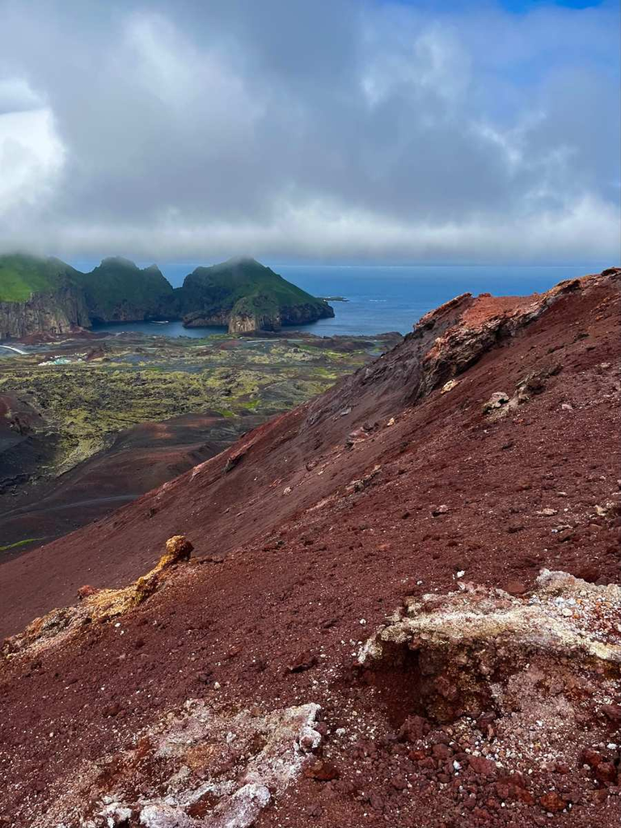

Day 3

Golden Circle

Thingvellir National Park, Gulfoss waterfall, lupine fields, Icelandic horses. Push toward the first South Coast overnight.

Day 4

South Coast

Seljalandsfoss, Skogafoss, Reynisfjara, Dyrholaey. Push to Diamond Beach and Glacier Lagoon.

Day 5

Hofn — Glacier Country

Glacier hike near Hofell — approximately 8 miles out and back, walk on the glacier. Geothermal hot spring in the afternoon — plan a few hours.

Dawson

Used AllTrails for updated reviews — landslides on some approaches. Look for trails with recent reviews. Guided hikes available if you want more time on the ice. The hot springs are very popular, especially on cold days. Worth it.

Day 6

Eastern Fjords

Drive the Eastern Fjords. No agenda — just drive and look. Stop whenever something catches your eye. Waterfalls everywhere. The drive up and over the mountain into Seydisfjordur is the most rugged section of the whole Ring Road.

Dawson

The eastern fjords are gorgeous to drive through. Definitely the most rugged part we drove on. Stop whenever.

Day 7

North to Akureyri

Continue north through Egilsstadir toward Akureyri. Second-largest city in Iceland — which still feels like a small town. Almost everyone in Iceland lives in the Reykjavik metro area.

Day 8

Lake Myvatn + Godafoss

Lake Myvatn: volcanic and geothermal landscape unlike anything else on the Ring Road. Godafoss waterfall.

Dawson

Myvatn is a proper destination. Volcanic landscape unlike anything else on the Ring Road.

Day 9

Interior Drive Back

Drive back toward Reykjavik via the interior. Grabrókarfell — huge volcanic crater on the Akureyri-to-Reykjavik stretch. Easy access from the road, massive payoff.

Days 10-11

Reykjavik

Hallgrimskirkja, Sun Voyager. Explore the city properly after 9 days on the road. Hrunalaug or Sky Lagoon if not done earlier. Debrief. Duty-free run. Fly home.

### What This Version Adds vs. the Short

The Eastern Fjords, Akureyri, Lake Myvatn, and the volcanic interior between Akureyri and Reykjavik. About 5 additional driving days and 3-4 more days of distinct experience. The full story of the island rather than the South Coast highlight reel.

### Logistics

Vehicle

Dacia Duster 4WD. Luggage tight — pack accordingly.

Roads

Route 1 fully paved. No F-roads required.

Accommodation

Airbnbs $220-350/night. Guesthouses $180-250 — often better value.

Monitoring

Road.is for closures. Vedur.is for conditions.

### Who This Is For

Groups who want the complete Iceland experience and have the time to do it right. Anyone who wants to tell the whole story of the island. The recommended version if time allows.

Version 3

## Northern Lights Short — 5 to 7 Days

Reykjavik + Golden Circle + South Coast in Winter — Late Feb / Early March

Medium-High Confidence — Research-Based

Same geography as the Summer Short, but a completely different trip. The South Coast in winter is dramatic, quiet, and built for aurora hunting. Ice caves, hot springs at their most satisfying, low-sun golden light on every waterfall. Ground costs 30-40% lower than summer. No puffins, no midnight sun — that is the trade.

Dawson

No firsthand winter experience — the summer route covers the same geography, but all winter conditions and aurora strategy here are research-based. The South Coast and Golden Circle that I know well are the foundation, but the season changes everything.

Research Adds

Late February to early March is the best aurora window. The equinox aurora boost (Russell-McPherron effect) increases geomagnetic activity. Days reach 10-12 hours of light — enough for driving and sightseeing — while nights are fully dark for aurora viewing. Blue ice caves in the Vatnajokull region are only accessible in winter and most stable in Feb-March.

### Day by Day

Day 1

Arrival + Setup

Fly into KEF. Duty-free. Drive toward Selfoss. Download Vedur.is. Check the aurora forecast for the week. Monitor the Bz index nightly — this is your primary tool for the whole trip.

Day 2

Golden Circle in Snow

Thingvellir under snow — quiet, beautiful, entirely different character. Gulfoss with ice formations. Push toward the South Coast. First aurora attempt after dark.

Day 3

South Coast + Aurora Hunting

Seljalandsfoss, Skogafoss, Reynisfjara, Dyrholaey if accessible. All waterfalls have a different visual character in winter — partially frozen, low golden light.

Aurora Strategy

Successful groups drive 100-150km at night to find clear skies. Cloud cover is the enemy — a high Kp forecast under thick Atlantic stratus is worthless. Commit to driving toward clear sky gaps. Waiting outside the hotel rarely works.

Day 4

Diamond Beach + Ice Caves

Diamond Beach and Glacier Lagoon — winter version: larger ice chunks, no boat tours, starkly beautiful. Ice cave tour in Vatnajokull — winter-only, book well in advance. Katla Ice Cave accessible year-round as backup.

Days 5-6

Return + Hot Springs + Reykjavik

Return along the South Coast. Hrunalaug hot spring or a local geothermal pool — hot springs are more dramatic when it is genuinely cold outside. Reykjavik: Hallgrimskirkja, Sun Voyager, Sky Lagoon. Final aurora attempt if skies cooperate.

Day 7

Fly Home

Depart KEF.

### What This Version Adds vs. Summer Short

Aurora probability. Winter-only ice caves. A dramatically different visual character on every waterfall and landscape. Fewer people at every stop. Meaningfully lower cost. Trades the midnight sun, puffins, and lupine for the full winter experience.

### Logistics

Vehicle

4WD required. Dacia Duster minimum. Studded tires standard on winter rentals.

Roads

Route 1 only. All F-roads closed in winter.

Accommodation

30-40% cheaper than summer. Most South Coast properties stay open.

Aurora Tools

Vedur.is for cloud forecasts. Monitor Kp and Bz index nightly.

### Who This Is For

Groups who want northern lights as the primary objective, are comfortable driving in winter conditions, and want a real cost advantage. Ideal for first-time Iceland visitors who do not need the full Ring Road.

Version 4

## Northern Lights Long — 10 to 12 Days

Full Ring Road in Winter — October or Late Feb / March

Medium-Low Confidence — High Ambition

The most ambitious version by a wide margin. This route requires genuine comfort with winter driving, full itinerary flexibility, and willingness to shelter in place when the Icelandic Met Office issues weather alerts. Achievable — but not forgiving.

Winter Driving Warning

Wind speeds in Iceland can exceed 35 m/s — strong enough to rip car doors off or push vehicles off the road. The East Fjords are the most exposed and dangerous section in winter. Do not rush this route. Build buffer days into every section.

Dawson

No firsthand winter experience. The route is the same as my summer version, but all winter conditions here are research-based. The Eastern Fjords in particular — gorgeous in summer, genuinely dangerous in winter.

Research Adds

Avoid December and January — daylight drops to 4-5 hours and sightseeing is severely limited. October and late February/March are the best windows. The East Fjords alone need two full days in winter versus one in summer.

### Day by Day

Day 1

Arrival

KEF arrival. Duty-free. Drive toward Selfoss. Download Vedur.is and Road.is — you will check both daily for the rest of the trip.

Day 2

Golden Circle + First Aurora Attempt

Thingvellir. Gulfoss. Push to South Coast. First aurora hunt after dark.

Day 3

South Coast

Seljalandsfoss, Skogafoss, Reynisfjara, Dyrholaey. Night: aurora hunting — commit to driving toward clear skies.

Day 4

Diamond Beach + Ice Caves

Diamond Beach. Glacier Lagoon. Ice cave tour — Vatnajokull or Katla. Book in advance.

Day 5

Hofn

Glacier hike if conditions allow. Geothermal hot spring. This is a good buffer day — if weather delayed you, use it to catch up.

Days 6-7

Eastern Fjords — Two Full Days

Drive slowly. Stop constantly. This is not a transit day — it is two transit days. The Eastern Fjords are the most exposed winter section of the Ring Road: narrow, iced over, wind-hammered. It is also some of the most beautiful driving on the island.

Weather Protocol

Red or Orange Met Office wind alert means do not drive. Full stop. Build this flexibility into the itinerary — it is not optional, it is the plan.

Day 8

Akureyri — Buffer Day

Explore Akureyri. This day exists primarily as a built-in buffer for weather delays. If the Eastern Fjords cost you an extra day, this absorbs it.

Day 9

Lake Myvatn + Godafoss

Myvatn. Godafoss. Aurora hunt from the north — often clearer skies than the south coast.

Day 10

Interior Drive

Drive back toward Reykjavik. Grabrókarfell crater stop.

Days 11-12

Reykjavik

Sky Lagoon. Final aurora attempt. The city feels different after 10 days on the road in winter — earned, warm, welcome. Fly home.

### What This Version Adds vs. Winter Short

The full island — Eastern Fjords, Akureyri, Lake Myvatn, the volcanic interior. Multiple aurora opportunities from different geographic locations, including the north where skies are often clearer. More experience per day, significantly higher execution risk.

### Logistics

Vehicle

Toyota Land Cruiser or Mitsubishi Pajero. Do not downgrade. 2WD is a safety risk.

Roads

Route 1 only. All F-roads closed. Check Road.is every single day.

Accommodation

30-40% cheaper than summer. Some rural guesthouses closed — confirm before booking.

Weather

Red/Orange Met Office alert = do not drive. Understand this protocol before you leave home.

### Who This Is For

Experienced groups comfortable with winter driving who want the full Ring Road and see the northern lights as the centerpiece. Not recommended for first-time Iceland visitors unless at least one person has driven in serious winter conditions. Best suited to a group that has already done the summer version and wants the full contrast.

At a Glance

## All Four Versions

|  | V1 Summer Short | V2 Summer Long | V3 Winter Short | V4 Winter Long |
| --- | --- | --- | --- | --- |
| Duration | 5-7 days | 10-12 days | 5-7 days | 10-12 days |
| Best Window | Late June | Late June | Late Feb-Mar | Oct or Late Feb-Mar |
| Route | South Coast | Full Ring Road | South Coast | Full Ring Road |
| Headline | Midnight sun, puffins, lupine | The definitive road trip | Aurora, ice caves, quiet | Full island in winter |
| Accommodation | $220-350/night | $180-350/night | 30-40% less | 30-40% less |
| Vehicle | Dacia Duster 4WD | Dacia Duster 4WD | 4WD + studded tires | Land Cruiser / Pajero |
| Confidence | High | High — Validated | Medium-High | Medium-Low |
| Risk | Low | Low | Moderate | High |

Savings Intelligence

## Where the money goes — and where it doesn't have to

#### Alcohol

Buy everything at the KEF duty-free on arrival. Not some of it — all of it. Prices on the island are 2-3x higher than the airport shop. This is the single easiest savings decision of the trip.

Dawson

Just do it. On arrival. No exceptions.

#### Food

Shop at Bonus or Kronan. Pick up a disposable BBQ and lamb steaks at Bonus — total cost for four people runs about $45 versus $200+ at a restaurant. Do this at least half the nights. Iceland is expensive for dining out; this is how you control the budget without eating badly.

#### Hot Springs

Skip Blue Lagoon. $100+/person, heavily touristed, not meaningfully better than alternatives. Sky Lagoon is $70 with better views. Hrunalaug is $15 and genuinely good — a small natural pool with almost no one around. The Lads pick: Hrunalaug.

#### Westman Islands Ferry

Car ferry runs about $110-150 for a car plus 4 people (2026 estimate). Best bang-for-buck excursion in Iceland — an entire volcanic island archipelago with puffin colonies for the cost of a mid-range dinner.

#### National Parks + Parking

All national park entry is free. Parking at major stops runs about ~$8/stop via the Parka app. Download it before you go.

#### Booking Windows

Summer 2026 rental availability is limited — the ideal booking window was early 2026. Check availability now and expect reduced options and higher prices. Winter bookings have more flexibility but book at least two months out.

Cost Model

## Per person, group of 4

Flights priced from ORD. DTW is seasonal via Icelandair or Delta (May-October) and may price slightly lower — worth checking both. Lean scenario: grocery-majority food, Hrunalaug over Sky Lagoon, no guided tours. Standard: mix of restaurants and groceries, one or two guided activities, Sky Lagoon included.

Summer Short (V1)

$1,800 - $2,600

5-7 days, lean to standard

Summer Long (V2)

$2,800 - $3,800

10-12 days, lean to standard

Winter Short (V3)

$1,400 - $2,100

5-7 days, 30-40% ground savings

Winter Long (V4)

$2,200 - $3,200

10-12 days, bigger vehicle required

Estimates include flights, accommodation share, rental car share, gas, food, and activities. Excludes the duty-free alcohol run. All figures directional — validate current fares and availability before booking.

What First-Timers Get Wrong

01

#### Booking in August 2026

Any year, August means peak crowds and peak prices on the South Coast. In 2026, it also means eclipse chaos across the entire western half of the island. Late June is better on every metric for a group not specifically targeting the eclipse.

02

#### Waiting Outside for the Aurora

Cloud cover is the enemy. A high Kp forecast under thick Atlantic stratus is worthless. Successful groups drive 100-150km to find clear sky and commit to it. Standing outside the hotel rarely delivers.

04

#### Choosing July Over Late June

Late June has midnight sun peak, lupine bloom, and puffins fully active — with fewer people than July. The difference is real and measurable.

05

#### Rushing the Eastern Fjords in Winter

Groups treat the Eastern Fjords as a transit day. It is not. It is the most exposed section of the Ring Road in bad weather and some of the most beautiful driving on the island. Two full days minimum in winter.

06

#### Paying City Prices for Alcohol

2-3x cheaper at KEF duty-free than any store on the island. Buy everything when you land. Everything.

07

#### Blue Lagoon Over Hrunalaug

Blue Lagoon is $100+ per person, heavily touristed, and not meaningfully better than alternatives. Hrunalaug is $15 and genuinely good. Sky Lagoon is $70 with better views. The Blue Lagoon is a photo op for people who did not plan ahead.

The Decision

## Helping you choose

### Summer or Winter?

Summer is the easier sell — midnight sun, puffins, green landscapes, everything open. Winter is a completely different trip. The aurora is real but not guaranteed. The driving is harder. The hot springs are better. The crowds are gone. If you want to see Iceland, summer. If you want to feel Iceland, winter.

### Northern Lights or Midnight Sun?

You cannot have both. Late June is midnight sun — it does not get dark. Aurora requires darkness. If northern lights are the priority, come in February or March. If midnight sun and puffins are the priority, late June. Do not book late August thinking you get both. You get neither well, and you pay eclipse pricing for the privilege.

"Highly highly highly recommend Iceland." Dawson — after completing the full Ring Road

One of the most accessible, self-drivable, genuinely otherworldly places on the planet. The Ring Road gives you a complete story. The South Coast gives you the best of it in less time. Either way, the group comes home with something worth talking about.

Before You Go

## Advance Booking Checklist

### All Versions

Rental car with 4WD, GP, and SAAP — book as early as possible for summer

Accommodation booked along the full route — do not freelance in summer

Parka app downloaded for national park parking

Vedur.is and Road.is bookmarked before departure

KEF duty-free: stock up on arrival, not after

Bonus/Kronan grocery stops planned for at least half the nights

### Summer Only

Westman Islands car ferry booked in advance — car + 4 people

Confirm F-road opening dates if planning any highland detours

Summer 2026 rental availability — limited; check now and expect higher prices

### Winter Only

Ice cave tour booked well in advance — Vatnajokull blue caves have limited slots

Confirm which rural guesthouses are open on your specific route

Vedur.is aurora app — use it every single night

Understand Red/Orange wind alert protocol before you leave home

The Lads Travel Co.

Personally validated trip planning.  
650+ spots rated across 20 cities. Real experience. Honest advice.

dangelobraden43@gmail.com

↑